# Pactical Machine Learning- Assignment 1

Amrutha Varshini

July 10, 2017

## Summary

Using devices such as Jawbone Up, Nike FuelBand, and Fitbit it is now possible to collect a large amount of data about personal activity relatively inexpensively. These type of devices are part of the quantified self movement – a group of enthusiasts who take measurements about themselves regularly to improve their health, to find patterns in their behavior, or because they are tech geeks. One thing that people regularly do is quantify how much of a particular activity they do, but they rarely quantify how well they do it. In this project, your goal will be to use data from accelerometers on the belt, forearm, arm, and dumbell of 6 participants. They were asked to perform barbell lifts correctly and incorrectly in 5 different ways.

The goal of this project is to predict the manner in which they did the execise.

## Loading Required Packages

```r
library(caret)
library(randomForest)
```

## Getting Data

```r
trainURL <- "https://d396qusza40orc.cloudfront.net/predmachlearn/pml-training.csv"
testURL <- "https://d396qusza40orc.cloudfront.net/predmachlearn/pml-testing.csv"
download.file(url=trainURL, destfile="Train.csv")
download.file(url=testURL, destfile="Test.csv")
training <- read.csv("Train.csv",row.names=1,na.strings = "")
testing <- read.csv("Test.csv",row.names=1,na.strings = "NA")
```

## Data Preprocessing

First we need shall remove the variables that variance close to Zero in training and testing data.Then we will remove the columns having missing values.We will also remove columns that seems to be irrelevant.

```r
# Remove variables having near zero covariates
nzc <- nearZeroVar(training,saveMetrics=TRUE)
training <- training[,!nzc$nzv]
testing <- testing[,!nzc$nzv]

# Remove variables with missing values
training_filterNA <- training[,(colSums(is.na(training)) == 0)]
testing_filterNA <- testing[,(colSums(is.na(testing)) == 0)]

# Remove unnecessary columns
colRem_train <- c("user_name","raw_timestamp_part_1","raw_timestamp_part_2","cvtd_timestamp","num_window")
colRem_test <- c("user_name","raw_timestamp_part_1","raw_timestamp_part_2","cvtd_timestamp","num_window","problem_id")
training_colRem <- training_filterNA[,!(names(training_filterNA) %in% colRem_train)]
testing_colRem <- testing_filterNA[,!(names(testing_filterNA) %in% colRem_test)]
```

We can slipt the training data into Training and Validation data.

```r
inTrain <- createDataPartition(y=training$classe, p=0.7, list=FALSE)
training_final <- training_colRem[inTrain,]
validation_final <- training_colRem[-inTrain,]
cor <- abs(sapply(colnames(training_final[, -ncol(training)]), function(x) cor(as.numeric(training_final[, x]), as.numeric(training_final$classe), method = "spearman")))
```

We observe that in the Test and Training data sets there are 52 predictors and 1 response.

On checking the correlations between the predictors and the outcome variable in the new training set, There doesn’t seem to be any predictors strongly correlated with the outcome variable, so linear regression model is not selected.

Random forest model may be more robust for this data. And in random forests, there is no need for cross-validation or a separate test set to get an unbiased estimate of the test set error. It is estimated internally, during the execution.

## Fitting Random forest model

We shall now fit the Random forest model on the Training Dataset and check correctness on the Validation Dataset.

```r
# Fit rf model
rfFit <- train(classe ~ ., method = "rf", data = training_final, importance = T, trControl = trainControl(method = "cv", number = 4))
validation_pred <- predict(rfFit, newdata=validation_final)
# Check  performance of model
confusionMatrix(validation_pred,validation_final$classe)
```

```
## Confusion Matrix and Statistics
##
##           Reference
## Prediction    A    B    C    D    E
##          A 1672    7    0    0    0
##          B    2 1128    9    0    1
##          C    0    4 1010   13    1
##          D    0    0    7  951    2
##          E    0    0    0    0 1078
##
## Overall Statistics
##
##                Accuracy : 0.9922
##                  95% CI : (0.9896, 0.9943)
##     No Information Rate : 0.2845
##     P-Value [Acc > NIR] : < 2.2e-16
##
##                   Kappa : 0.9901
##  Mcnemar's Test P-Value : NA
##
## Statistics by Class:
##
##                      Class: A Class: B Class: C Class: D Class: E
## Sensitivity            0.9988   0.9903   0.9844   0.9865   0.9963
## Specificity            0.9983   0.9975   0.9963   0.9982   1.0000
## Pos Pred Value         0.9958   0.9895   0.9825   0.9906   1.0000
## Neg Pred Value         0.9995   0.9977   0.9967   0.9974   0.9992
## Prevalence             0.2845   0.1935   0.1743   0.1638   0.1839
## Detection Rate         0.2841   0.1917   0.1716   0.1616   0.1832
## Detection Prevalence   0.2853   0.1937   0.1747   0.1631   0.1832
## Balanced Accuracy      0.9986   0.9939   0.9904   0.9923   0.9982
```

## Plotting the importance of Various Predictors

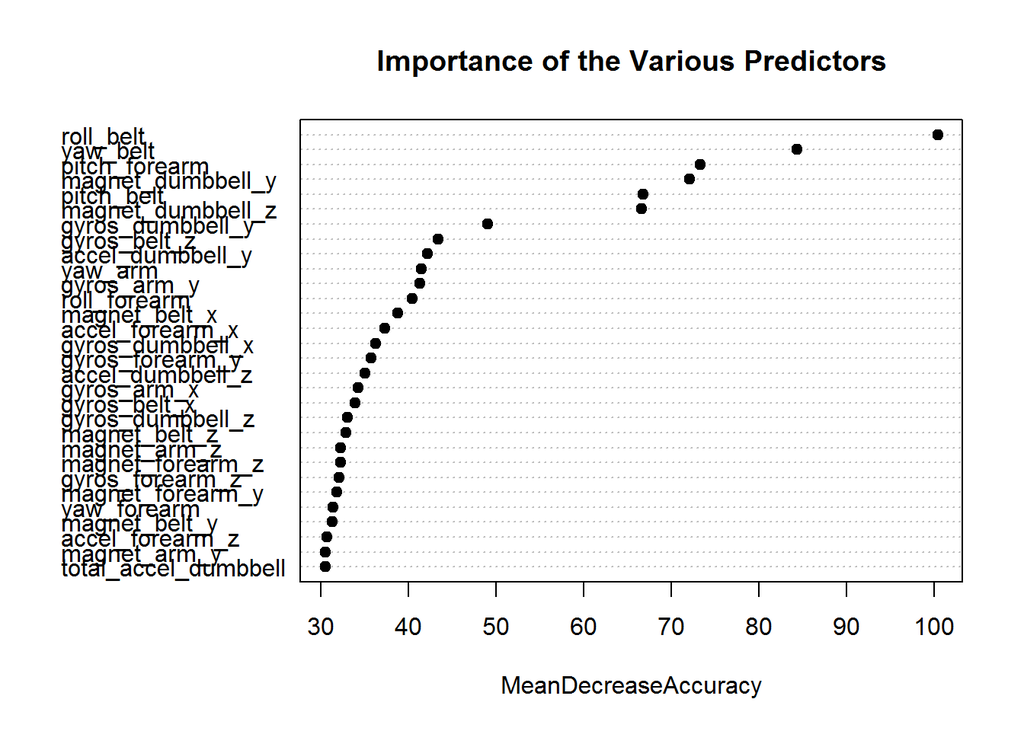

```r
imp <- varImp(rfFit)$importance
varImpPlot(rfFit$finalModel, sort = TRUE, type = 1, pch = 19, col = 1, cex = 1, main = "Importance of the Various Predictors")
```

## Final Prediction

Now we shall use the random forest model to predict on the testing set without the outcome variable and save the prediction output.

```r
final_pred <- predict(rfFit, newdata=testing_colRem)
final_pred
```

```
##  [1] B A B A A E D B A A B C B A E E A B B B
## Levels: A B C D E
```

## Results

We have fit a Random Forest Model with 4-fold cross validation. And have obtained the above predictions and same has been submitted as the answers of the Quiz.